# CVDRM PSED Report

### Admissions for renal failure

**Age**

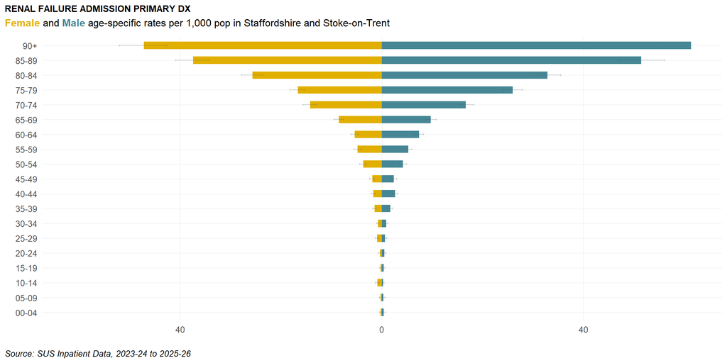

**Sex or Stated Gender**

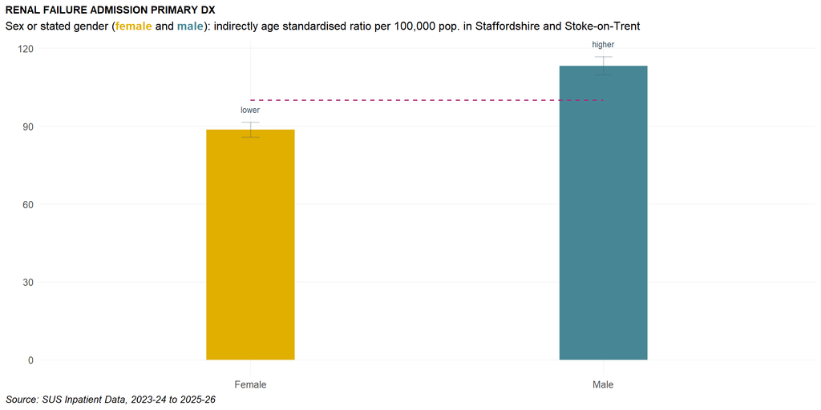

**Ethnicity**

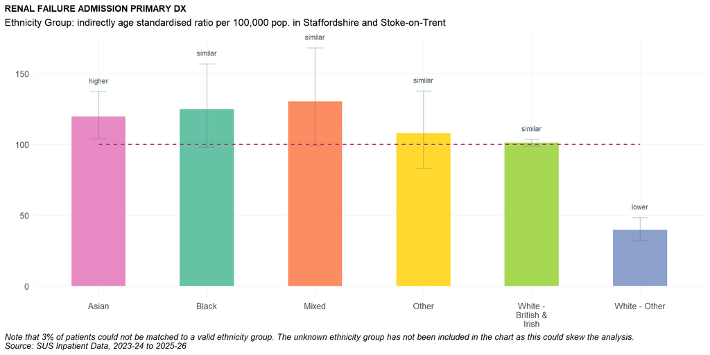

**Deprivation**

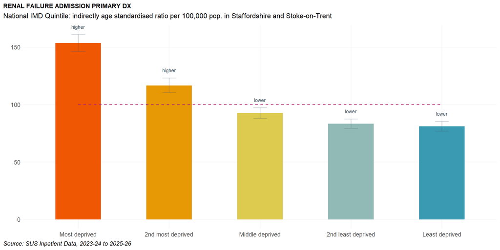

**Urban-Rural**

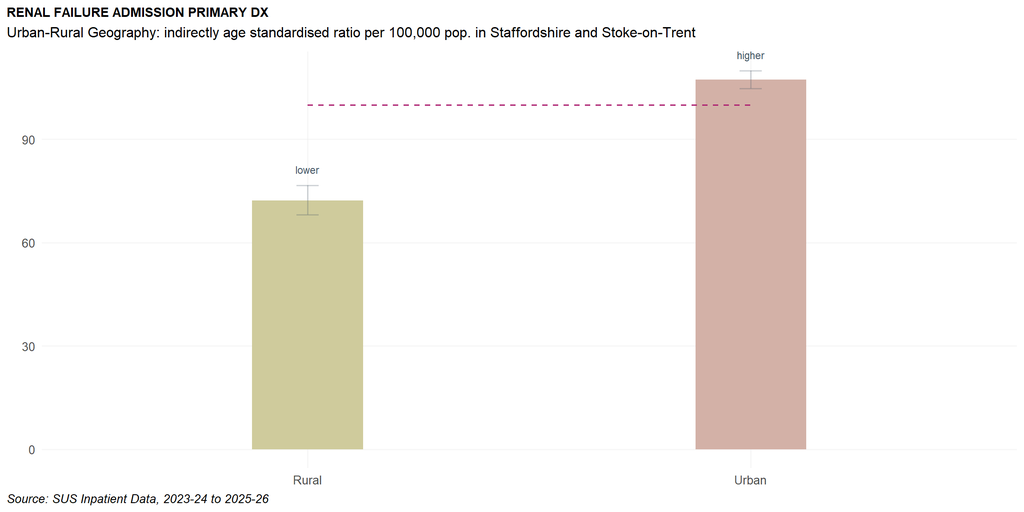

- Rates are highest in the 90+ age group, whilst the median age is approx. 76 years.
- Males had a significantly higher rate, whilst females had a significantly lower rate.
- Patients of Asian ethnicity had a significantly higher rate, whilst patients of White - Other ethnicity had a significantly lower rate.
- Patients from the two most deprived groups had a significantly higher rate whilst patients from the two least deprived groups had a significantly lower rate.
- Patients from urban areas had a significantly higher rate, whilst patients from rural areas had a significantly lower rate.